# reshaping data with `tidyr`

Author

Casey Schine adapted from Emily Malcolm-White

The goal of `tidyr` is to help you create tidy data.

The tidyverse works very well with “long” data. Where each column is a variable, each row contains a single observation and each cell contains a value for each observation.

# Today’s dataset: `portal`

The Portal Project dataset comes from a long-term ecological study that began in 1977 near Portal, Arizona, USA. Researchers have been collecting data continuously for nearly 50 years, making it one of the longest-running ecological studies in the world.

```r
#LOAD PACKAGES
library(tidyverse)

#LOAD DATA
portal_rodent <- read.csv("https://github.com/weecology/PortalData/raw/main/Rodents/Portal_rodent.csv")
```

```r
# SOME SUMMARY STATS
portal_wgt_summary <- portal_rodent |>
  filter(!is.na(wgt)) |> #filter out NAs
  group_by(plot, species) |> # group by plot and species
  summarize(mean_wgt = mean(wgt)) # calculate mean weight for each unique plot/species

portal_wgt_summary
```

```
# A tibble: 480 × 3
# Groups:   plot [25]
    plot species mean_wgt
   <int> <chr>      <dbl>
 1     1 BA          9.1
 2     1 DM         43.5
 3     1 DO         49.4
 4     1 DS        129.
 5     1 OL         33.2
 6     1 OT         24.3
 7     1 PB         32.0
 8     1 PE         22.3
 9     1 PF          7.12
10     1 PH         31.4
# ℹ 470 more rows
```

# Pivot Wider with `portal`

What is wide data?

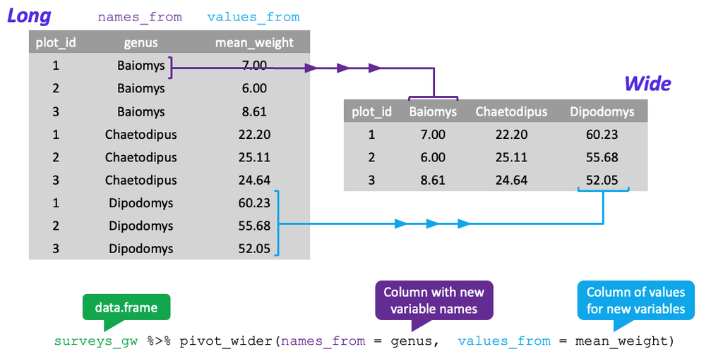

**`pivot_wider()` reduces the number of rows and increases the number of columns.**

Practicing transforming this data from long to wide format:

```r
# first let's look at the help documentation to see what this function wants
# ?pivot_wider
# what does it need???

wide_portal <- portal_wgt_summary |>
  pivot_wider(names_from=species,
              values_from=mean_wgt)

wide_portal
```

```
# A tibble: 25 × 28
# Groups:   plot [25]
    plot    BA    DM    DO    DS    OL    OT    PB    PE    PF    PH    PI    PL
   <int> <dbl> <dbl> <dbl> <dbl> <dbl> <dbl> <dbl> <dbl> <dbl> <dbl> <dbl> <dbl>
 1     1  9.1   43.5  49.4  129.  33.2  24.3  32.0  22.3  7.12  31.4  17.4  25.2
 2     2  9.4   43.4  49.1  123.  31.7  24.7  33.3  21.9  7.18  32.5  16    25.2
 3     3  8.66  43.0  49.5  128.  31.0  23.6  32.5  22.5  7.58  28    17.1  22.2
 4     4 10.2   43.5  49.2  118.  31.8  24.1  30.7  21.1  7.85  NA    18.4  NA
 5     5  9.14  43.7  49.8  111.  30.1  24.8  32.0  21.7  8.25  29    NA    24.6
 6     6  9.33  42.6  48.8  114.  30.5  24.2  31.5  21.8  7.89  NA    17    25
 7     7 10     44.2  49.3  126.  32.2  24.4  33.4  23.1  9     30    NA    25.2
 8     8 10.2   43.4  48.8  127.  28.8  23.9  30.2  21.6  7.06  41    19.8  28
 9     9 10.2   43.6  48.7  115.  30.4  23.6  30.0  21.6  7.22  NA    16.7  19
10    10 10     44.1  51.7  130   34.4  19.6  33.2  22.6  8     NA    NA    20.8
# ℹ 15 more rows
# ℹ 15 more variables: PM <dbl>, PP <dbl>, RM <dbl>, RO <dbl>, SF <dbl>,
#   SH <dbl>, `NA` <dbl>, OX <dbl>, PX <dbl>, RF <dbl>, SO <dbl>, RX <dbl>,
#   DX <dbl>, SS <dbl>, SX <dbl>
```

`pivot_wider()` is helpful when:

- You have key-value pairs (e.g., variable names and values) that you want to turn into actual columns.
- You want to summarize or compare values side-by-side across categories or time periods.
- You’re preparing data for modeling or presentation where wide format is more natural.

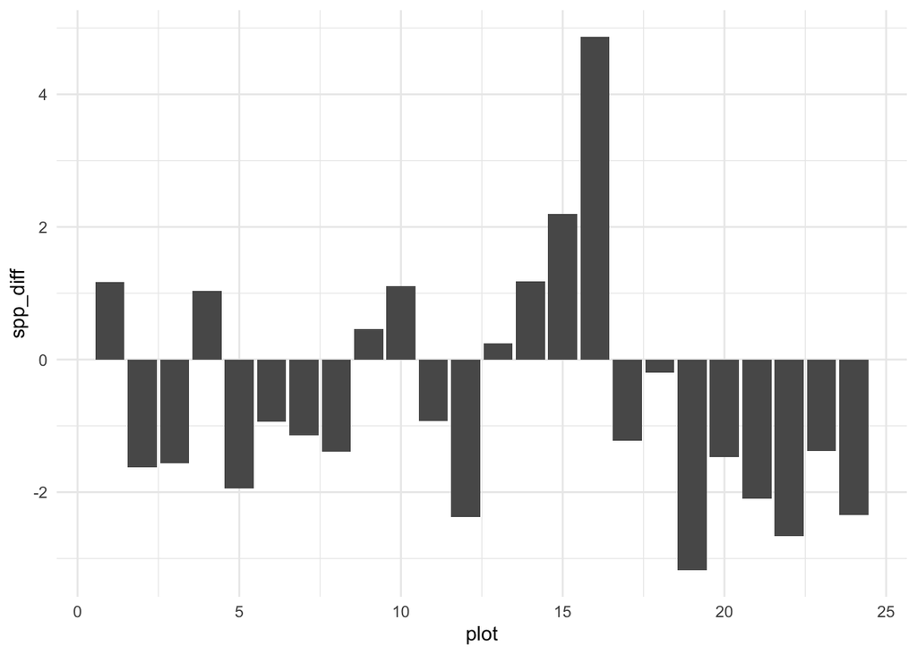

```r
# pivot_wider uses
# calculate difference between species abundance across plots
# calc diff between OL and PB

wide_portal <- wide_portal |>
  mutate(spp_diff=OL-PB)



# plot the diff

wide_portal |>
  mutate(spp_diff=OL-PB) |>
  ggplot() +
  geom_col(aes(x=plot, y=spp_diff)) +
  theme_minimal()
```

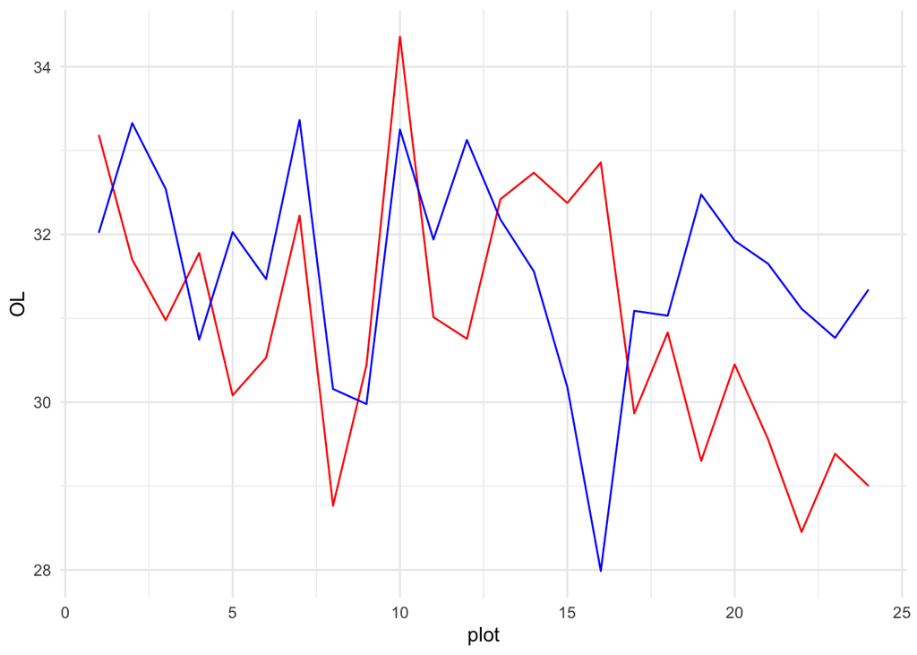

```r
# plot both without reshaping the data

wide_portal |>
  ggplot() +
  geom_line(aes(x=plot, y=OL), color="red") +
  geom_line(aes(x=plot, y=PB), color="blue") +
  theme_minimal()
```

# Pivot Longer

`pivot_longer()` is helpful when:

- You have multiple columns representing the same kind of data (e.g., test scores, years, conditions) and you want to gather them into key-value pairs.

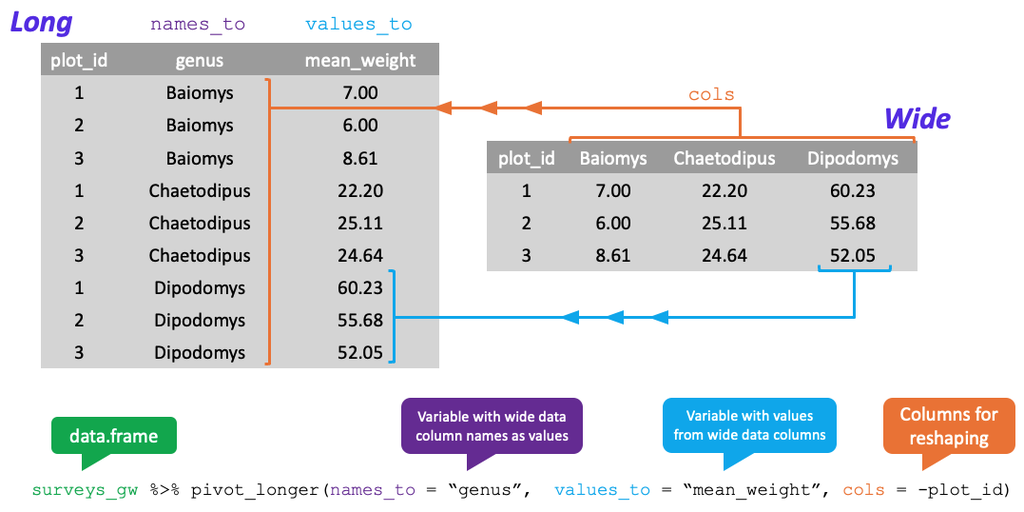

**`pivot_longer()` reduces the number of columns and increases the number of rows**

Practicing transforming this data from wide to long format:

```r
# look at pivot_longer documentation
# ?pivot_longer

# remake wide_portal because I added some things
wide_portal <- portal_wgt_summary |>
  pivot_wider(names_from=species, values_from= mean_wgt)

# use column names

long_portal <- wide_portal |>
  pivot_longer(cols=BA:SX,
               names_to="species",
               values_to="weight")

long_portal
```

```
# A tibble: 675 × 3
# Groups:   plot [25]
    plot species weight
   <int> <chr>    <dbl>
 1     1 BA        9.1
 2     1 DM       43.5
 3     1 DO       49.4
 4     1 DS      129.
 5     1 OL       33.2
 6     1 OT       24.3
 7     1 PB       32.0
 8     1 PE       22.3
 9     1 PF        7.12
10     1 PH       31.4
# ℹ 665 more rows
```

```r
# same thing but without plot

long_portal <- wide_portal |>
  pivot_longer(cols=!plot,
               names_to="species",
               values_to="weight")

long_portal
```

```
# A tibble: 675 × 3
# Groups:   plot [25]
    plot species weight
   <int> <chr>    <dbl>
 1     1 BA        9.1
 2     1 DM       43.5
 3     1 DO       49.4
 4     1 DS      129.
 5     1 OL       33.2
 6     1 OT       24.3
 7     1 PB       32.0
 8     1 PE       22.3
 9     1 PF        7.12
10     1 PH       31.4
# ℹ 665 more rows
```

```r
# same thing with column numbers
long_portal <- wide_portal |>
  pivot_longer(cols=2:28,
               names_to="species",
               values_to="weight")

long_portal
```

```
# A tibble: 675 × 3
# Groups:   plot [25]
    plot species weight
   <int> <chr>    <dbl>
 1     1 BA        9.1
 2     1 DM       43.5
 3     1 DO       49.4
 4     1 DS      129.
 5     1 OL       33.2
 6     1 OT       24.3
 7     1 PB       32.0
 8     1 PE       22.3
 9     1 PF        7.12
10     1 PH       31.4
# ℹ 665 more rows
```

# Common Pitfalls

## Missing Combinations in `pivot_wider()`

```r
example <- tibble(species_id = c("DM", "DM", "DO"),
                  month = c("jan", "feb", "jan"),
                  avg_weight = c(40, 38, 31))

example
```

```
# A tibble: 3 × 3
  species_id month avg_weight
  <chr>      <chr>      <dbl>
1 DM         jan           40
2 DM         feb           38
3 DO         jan           31
```

```r
#pivot example wider

example |>
  pivot_wider(names_from=month,
              values_from=avg_weight)
```

```
# A tibble: 2 × 3
  species_id   jan   feb
  <chr>      <dbl> <dbl>
1 DM            40    38
2 DO            31    NA
```

```r
# fill missing value with values_fill

example |>
  pivot_wider(names_from=month,
              values_from=avg_weight,
              values_fill=0)
```

```
# A tibble: 2 × 3
  species_id   jan   feb
  <chr>      <dbl> <dbl>
1 DM            40    38
2 DO            31     0
```

```r
# fille missing value with missing value numeric code
example |>
  pivot_wider(names_from=month,
              values_from=avg_weight,
              values_fill=-999)
```

```
# A tibble: 2 × 3
  species_id   jan   feb
  <chr>      <dbl> <dbl>
1 DM            40    38
2 DO            31  -999
```

Fix: Use `values_fill` to replace missing values with 0 (or another placeholder)

## Duplicate combinations in `pivot_wider()`

```r
example <- tibble(species_id = c("DM", "DM", "DO"),
                  month = c("jan", "jan", "jan"),
                  avg_weight = c(40, 42, 31))

example
```

```
# A tibble: 3 × 3
  species_id month avg_weight
  <chr>      <chr>      <dbl>
1 DM         jan           40
2 DM         jan           42
3 DO         jan           31
```

```r
# pivot new example wider
example |>
  pivot_wider(names_from=month,
              values_from=avg_weight)
```

```
# A tibble: 2 × 2
  species_id jan
  <chr>      <list>
1 DM         <dbl [2]>
2 DO         <dbl [1]>
```

```r
#look at the result and warning message

#now use values_fn to tell R how to handle duplicates (this is suggested in the warning)

# with values_fn = mean
example |>
  pivot_wider(names_from=month,
              values_from=avg_weight,
              values_fn=mean)
```

```
# A tibble: 2 × 2
  species_id   jan
  <chr>      <dbl>
1 DM            41
2 DO            31
```

```r
# with values_fn = max

example |>
  pivot_wider(names_from=month,
              values_from=avg_weight,
              values_fn=max)
```

```
# A tibble: 2 × 2
  species_id   jan
  <chr>      <dbl>
1 DM            42
2 DO            31
```

Fix: Tell R how to combine duplicates — for example, by taking the mean: `values_fn = mean`

## Column names encode multiple variables in `pivot_longer()`

```r
example <- tibble(species_id = c("DM", "DO"),
                  weight_male = c(40, 32),
                  weight_female = c(38, 31))

example
```

```
# A tibble: 2 × 3
  species_id weight_male weight_female
  <chr>            <dbl>         <dbl>
1 DM                  40            38
2 DO                  32            31
```

```r
# basic pivot_longer

example |>
  pivot_longer(cols=2:3,
               names_to="names",
               values_to="values")
```

```
# A tibble: 4 × 3
  species_id names         values
  <chr>      <chr>          <dbl>
1 DM         weight_male       40
2 DM         weight_female     38
3 DO         weight_male       32
4 DO         weight_female     31
```

```r
# pivot_longer but define cols using starts_with()


example |>
  pivot_longer(cols=starts_with("weight"),
               names_to="names",
               values_to="values")
```

```
# A tibble: 4 × 3
  species_id names         values
  <chr>      <chr>          <dbl>
1 DM         weight_male       40
2 DM         weight_female     38
3 DO         weight_male       32
4 DO         weight_female     31
```

Divide column names as part of pivot:

```r
# from the help documentation:
# ".value" indicates that the corresponding component of the column name defines the name of the output column containing the cell values, overriding values_to entirely.

# use names_to = names_to = c(".value", "sex")
# use names_sep = "_"

example |>
  pivot_longer(cols=starts_with("weight"),
               names_to=c(".value", "sex"),
               values_to="values",
               names_sep="_")
```

```
# A tibble: 4 × 3
  species_id sex    weight
  <chr>      <chr>   <dbl>
1 DM         male       40
2 DM         female     38
3 DO         male       32
4 DO         female     31
```

```r
# What if the name is in a different order, sex first and then weight
example <- tibble(species_id = c("DM", "DO"),
                  male_weight = c(40, 32),
                  female_weight = c(38, 31))

example
```

```
# A tibble: 2 × 3
  species_id male_weight female_weight
  <chr>            <dbl>         <dbl>
1 DM                  40            38
2 DO                  32            31
```

```r
# change the order of names_to = c()
example |>
  pivot_longer(cols=ends_with("weight"),
               names_to=c("sex", ".value"),
               values_to="values",
               names_sep="_")
```

```
# A tibble: 4 × 3
  species_id sex    weight
  <chr>      <chr>   <dbl>
1 DM         male       40
2 DM         female     38
3 DO         male       32
4 DO         female     31
```

This way of naming columns by parsing the names of the variables really comes in handy when you have more than one variable.

```r
example <- tibble(species_id = c("DM", "DO"),
                  male_weight = c(40, 32),
                  female_weight = c(38, 31),
                  male_length = c(25, 28),
                  female_length  = c(22, 24))

example
```

```
# A tibble: 2 × 5
  species_id male_weight female_weight male_length female_length
  <chr>            <dbl>         <dbl>       <dbl>         <dbl>
1 DM                  40            38          25            22
2 DO                  32            31          28            24
```

```r
# pivot_longer for the new example
example |>
  pivot_longer(cols=2:5,
               names_to=c("sex", ".value"),
               values_to="values",
               names_sep="_")
```

```
# A tibble: 4 × 4
  species_id sex    weight length
  <chr>      <chr>   <dbl>  <dbl>
1 DM         male       40     25
2 DM         female     38     22
3 DO         male       32     28
4 DO         female     31     24
```

# In Groups

Reshape the rodents data frame with year as columns, plot as rows, and the number of species per plot as the values. You will need to summarize before reshaping, and use the function `n_distinct()` to get the number of unique species within a particular chunk of data. It’s a powerful function! See ?n_distinct for more.

```r
portal_rodent |>
  group_by(plot, year) |>
  summarize(spp_num=n_distinct(species)) |>
  pivot_wider(names_from=year, values_from=spp_num)
```

```
# A tibble: 25 × 51
# Groups:   plot [25]
    plot `1977` `1978` `1979` `1980` `1981` `1982` `1983` `1984` `1985` `1986`
   <int>  <int>  <int>  <int>  <int>  <int>  <int>  <int>  <int>  <int>  <int>
 1     1      4      5      7      9      8      9     10      9      6      5
 2     2      9      9      9     11      9     12     12     12     10      7
 3     3      9      8      6      9      8     13     12     12      9      8
 4     4      5      5      5      7      6      6      8      5      7      5
 5     5      6      4      4      7      6      8      9     10      5      2
 6     6      4      8      6      8      7     13     13     11      8      8
 7     7      4      2      4      4      2      6      4      4      5      4
 8     8      4      7      5      8      9     11      8      8      7      6
 9     9      6      6      6      8      8      8     10      7      8      5
10    10      3      1      4      7      8      9      5      3      4      2
# ℹ 15 more rows
# ℹ 40 more variables: `1987` <int>, `1988` <int>, `1989` <int>, `1990` <int>,
#   `1991` <int>, `1992` <int>, `1993` <int>, `1994` <int>, `1995` <int>,
#   `1996` <int>, `1997` <int>, `1998` <int>, `1999` <int>, `2000` <int>,
#   `2001` <int>, `2002` <int>, `2003` <int>, `2004` <int>, `2005` <int>,
#   `2006` <int>, `2007` <int>, `2008` <int>, `2009` <int>, `2010` <int>,
#   `2011` <int>, `2012` <int>, `2013` <int>, `2014` <int>, `2015` <int>, …
```